# Project Report

X. Zhang

4/30/2019

# Abstract:

Are foreign policy hawks cue-takers rallying around the political elite or jingoistic masses driven by emotion? What are the sources of hawkish foreign policy preference in the time of international dispute escalation? Two schools of thought offer divergent answers to the questions. A top-down elite cue model asserts that due to information asymmetry between the uninformed public and the informed elite, the elite will be able to shape public opinion on the use of force through the supply of cues. A bottom-up psychological approach advanced by political psychologists of international relations argues that a lack of information does not preclude individual members of the public from forming hawkish preference using their values, dispositions, and emotions as heuristics. This paper offers a bottom-up theory of hawkishness by drawing on Appraisal-Tendency Framework (ATF) of emotion. It argues that conflicts are anger-inducing events. The emotion of anger, in turn, makes individual more hawkish independent of elite cues. In a sense, hawkishness is an instinctual emotional preference that does not depend on an informational basis. I put the theory to test by analyzing the statistical association between organic expression of anger and the expression of hawkishness, controlling for elite cues. Specifically, I use supervised machine learning classification of Chinese social media texts to measure public emotion and hawkishness and Chinese Foreign Ministry daily press briefing transcripts to measure hawkish elite cues. The results of cross-unit and temporal analysis yield three findings: (1) A strong positive correlation between expressed anger and expressed hawkishness. (2) A lack of significant association between hawkish elite cues and hawkish public preference during episodes of international dispute escalation events. (3) a significant but negative correlation between hawkish cues and hawkish public preference during non-escalation periods.

# Research Design:

I test the theory through the analysis of the organic expressions of anger and hawkish foreign policy preferences on Chinese social media. The empirical investigation proceeds in two stages. In the first classification stage, I manually code short media posts based on the emotion expressed as well as other relevant covariates such as expression of confidence in national power and support for the use of force. The manually coded example data is then used as training and testing sets for supervised machine learning models, which classifies the public anger and hawkishness in a massive amount of social media posts.

In the second analysis stage, I explore if escalation of international disputes increases the likelihood of anger expression. I run a set of logistic regress models to test the hypotheses that hawkishness expression has a positive association with expression of anger in the same post, adjusting for the latest elite cue and other control variables. I also test the robustness of the results by controlling for elite cues for anger, excluding the summer of protest, or excluding episodes of dispute escalation altogether. The elite cue model expects the hawkishness of individual in China will mirror the elite cue, propagated in the official media. On the contrary, I expect the coefficient of anger to be significant and positive.

# Data on Hawkishness and Anger.

To tests these hypotheses empirically, the project will use China’s Twitter-like Weibo(microblog) data. The specific dataset used contains 220 million posts by randomly sampled users who had more than 1000 followers in 2012, including censored posts (Fu & Chau, 2013). For the year 2012, there are 14,388,381 unique users in the raw data. China experienced a number of dispute escalation events in 2012, including the China-Philippine Huangyan Islets/Scarborough Shoal standoff in April, and Japan’s nationalization of Diaoyu/Senkaku Islands in August and September. Both escalations are landmark events in the recent intensification of geopolitical conflicts in Asia, attracting significant public attention and protests across China, which offered opportunities to compare the difference of emotion before and after two salient escalation events. In the pre-processing stage, I first identify posts that are potentially relevant to the two international disputes in 2012 using a keyword rule. I filter out 376,716 potentially relevant posts.

```r
library(easypackages)
libraries("tidyverse","here", "purrr", "magrittr","gtools")

#key word lists
SCS_keywords <- c("黄岩岛", "斯卡伯勒浅滩", "南海", "中沙群岛")
ECS_keywords <- c("钓鱼岛", "尖阁诸岛", "保钓")
Both_keywords<- c("黄岩岛", "斯卡伯勒浅滩", "南海", "中沙群岛", "钓鱼岛", "尖阁诸岛", "保钓")

Both_keywords %<>%
  paste(collapse = "|")

#write  a keyword extraction function

extract_relevant <- function(df) {
  df %>%
    filter(str_detect(text, Both_keywords))
}

#forloop for rule-based data filtering and merging
#https://hub.hku.hk/cris/dataset/dataset107483 download the data and place them in a folder named "Data" under working directory

datafiles <- list.files(here("Data"))

datafiles <- mixedsort(sort(datafiles))

Week1 <- read_csv(here("Data/week1.csv"),guess_max = min(100000, Inf))

relevant <- extract_relevant(Week1)

i=1

for (file in datafiles[2:52]) {
  dfn <- read_csv(here("Data",file), guess_max = min(100000, Inf))
  extracted <- extract_relevant(dfn)
  relevant <- full_join(relevant,extracted)
  i=i+1
  print(i)
}

relevantposts <- relevant

head(relevantposts$text, 100)


#example set
sample_1000 <- sample_n(relevant, size=1012, replace = FALSE)
write_csv(sample_1000, "sample_1000.csv")
```

A random sample of 1012 posts are then drawn from the relevant posts to be hand coded as the training set. Therefore, the unit of analysis is a microblog post.

```r
library(tidytext)
library(tidyverse)
library(tmcn)
library(stringr)
library(jiebaR)
library(tm)
library(stopwords)
library(caret) #ML
library(randomForest)
library(e1071)
library(LiblineaR) #svm
library(rpart)

#data loading

train1 <-read_csv("Classification.csv") # the original
train1$Markers <- NULL # removing uncoded posts

any(is.na(train1$Text))
any(is.na(train1$Text))

t1 <- train1[complete.cases(train1), ]

trainset <- t1

####
# example:
trainset[43,]$Text
# [805] "中国要出个普京式的领导人，卡斯特罗式的防长才行。要不像朱镕基总理式的也行。 //@uII5JZPV3： 日本没有任何诚意真心解决钓鱼岛问题。对付豺狼最好的办法不是忍让，而应该采取针锋相对的强硬态度。今天中国的国力增强了，绝不能容忍外人占我祖国的一寸河山。中国应该集中兵力、财力，狠狠的教训这只豺"

#### creating dummay for each variable:
trainset$Anger <- as.integer(str_detect(t1$Tag,"Anger"))
trainset$Hawk <- as.integer(str_detect(t1$Tag,"Hawkish"))
trainset$Dove <- as.integer(str_detect(t1$Tag,"Dovish"))
trainset$Protest <- as.integer(str_detect(t1$Tag,"Protests and collective action"))
trainset$Information <- as.integer(str_detect(t1$Tag,"Information"))
trainset$Power <- as.integer(str_detect(t1$Tag,"Power"))
trainset$News <- as.integer(str_detect(t1$Tag,"News"))
trainset$Irrelevant<-as.integer(str_detect(t1$Tag,"Irrelevant"))
trainset$ID <- rownames(trainset) #document ID
trainset$ID <- as.integer(trainset$ID)
trainset$Tag <- NULL

trainset$Anger <- as.factor(trainset$Anger)
trainset$Hawk <- as.factor(trainset$Hawk)
trainset$Dove <- as.factor(trainset$Dove)
trainset$Protest <- as.factor(trainset$Protest)
trainset$Information <- as.factor(trainset$Information )
trainset$Power <- as.factor(trainset$Power)
trainset$News <- as.factor(trainset$News)
trainset$Irrelevant<- as.factor(trainset$Irrelevant)


####

summary(trainset)

stop_words_cn <- as.tibble(stopwords(language = "zh", source = "misc"))
names(stop_words_cn)[1] <- "word"

#Create a tidy format

##       ID  cong billnum  h_or_sen major word
##    <int> <int>   <int> <fct>    <int> <chr>
##  1     1   107    4499 HR          18 suspend
##  2     1   107    4499 HR          18 temporarili

trainset_tokens <- trainset %>%
  unnest_tokens(output = word, input = Text)


#%>%
 # anti_join(stop_words_cn)

# pre-subsample descriptive stats
trainset %>%
  keep(is.factor) %>%                     # Keep only numeric columns
  gather() %>%                             # Convert to key-value pairs
  ggplot(aes(value)) +                     # Plot the values
  facet_wrap(~ key, scales = "free") +   # In separate panels
  geom_bar() + ggtitle("Example Set Posts")  # as density

trainset_dtm <- trainset_tokens %>%
  # get count of each token in each document
  count(ID, word) %>%
  # create a document-term matrix with all features and tf weighting
  cast_dtm(document = ID, term = word, value = n)

trainset_dtm <- removeSparseTerms(trainset_dtm, sparse = .991)


trainset_tfidf <- trainset_tokens %>%
    count(Anger, word) %>%
    bind_tf_idf(term = word, document = Anger, n = n)

# sort the data frame and convert word to a factor column
plot_trainset_tfidf <- trainset_tfidf %>%
  arrange(desc(tf_idf)) %>%
  mutate(word = factor(word, levels = rev(unique(word))))


# graph the top 10 tokens for 4 categories
plot_trainset_tfidf %>%
  filter(Anger %in% c(1)) %>%
  mutate(Anger = factor(Anger, levels = c(0,1),
                        labels = "Anger")) %>%
  group_by(Anger) %>%
  top_n(50) %>%
  ungroup() %>%
  ggplot(aes(word, tf_idf)) +
  geom_col() +
  labs(x = NULL, y = "tf-idf") +
  facet_wrap(~Anger, scales = "free") +
  coord_flip()

#hawkish words
trainset_tfidf <- trainset_tokens %>%
  count(Hawk, word) %>%
  bind_tf_idf(term = word, document = Hawk, n = n)

plot_trainset_tfidf <- trainset_tfidf %>%
  arrange(desc(tf_idf)) %>%
  mutate(word = factor(word, levels = rev(unique(word))))

#hawkish words
plot_trainset_tfidf %>%
  filter(Hawk %in% c(1)) %>%
  mutate(Hawk = factor(Hawk, levels = c(0,1),
                        labels = "Hawk")) %>%
  group_by(Hawk) %>%
  top_n(30) %>%
  ungroup() %>%
  ggplot(aes(word, tf_idf)) +
  geom_col() +
  labs(x = NULL, y = "tf-idf") +
  facet_wrap(~Hawk, scales = "free") +
  coord_flip()

##             ############ Estimate models ######################

# Support Vector Machine with weights: svmLinearWeights

#################

#train test-split Anger
meta <- tibble(ID = as.numeric(dimnames(trainset_dtm)[[1]])) %>%
  left_join(trainset[!duplicated(trainset$ID), ], by = "ID")

set.seed(2019)
trainIndex <- createDataPartition(trainset$Anger, p = 0.8, list = FALSE, times = 1)

data_df_train <- trainset_dtm[trainIndex, ] %>% as.matrix() %>% as.data.frame()
data_df_test <- trainset_dtm[-trainIndex, ] %>% as.matrix() %>% as.data.frame()

response_train <- meta$Anger[trainIndex]

################ #Support Vector Machine Accuracy : 0.8663

trctrl <- trainControl(method = "none")

svm_mod <- train(x = data_df_train,
                 y = as.factor(response_train),
                 method = "svmLinearWeights2",
                 trControl = trctrl,
                 tuneGrid = data.frame(cost = 1,
                                       Loss = 0,
                                       weight = 1))

svm_pred <- predict(svm_mod,
                    newdata = data_df_test)

svm_cm <- confusionMatrix(svm_pred, meta[-trainIndex, ]$Anger)
svm_cm

#tuning hyperparameter
fitControl <- trainControl(method = "repeatedcv",
                           number = 3,
                           repeats = 3,
                           search = "grid")


# tuned svm Accuracy Anger model: 0.8812
svm_mod_tuning <- train(x = data_df_train,
                 y = as.factor(response_train),
                 method = "svmLinearWeights2",
                 trControl = fitControl,
                 tuneGrid = data.frame(cost = 3,
                                       Loss = 0,
                                       weight = seq(0.5, 1.5, 0.1)))

svm_pred_tuned <- predict(svm_mod_tuning,
                    newdata = data_df_test)

svm_cm_tuned <- confusionMatrix(svm_pred_tuned, meta[-trainIndex, ]$Anger)

svm_mod_tuning$results


#######################


#we can plot the train object to see which value is highest.
plot(svm_mod_tuned)



#                     LogitBoost Accuracy  : 0.8069
logitboost_mod <- train(x = data_df_train,
                        y = as.factor(response_train),
                        method = "LogitBoost",
                        trControl = trctrl)
logitboost_pred <- predict(logitboost_mod,
                           newdata = data_df_test)

logitboost_cm <- confusionMatrix(logitboost_pred, meta[-trainIndex, ]$Anger)
logitboost_cm

# Random forest #Accuracy : 0.8416
rf_mod <- train(x = data_df_train,
                y = as.factor(response_train),
                method = "ranger",
                trControl = trctrl,
                tuneGrid = data.frame(mtry = floor(sqrt(dim(data_df_train)[2])),
                                      splitrule = "gini",
                                      min.node.size = 1))

rf_pred <- predict(rf_mod,
                   newdata = data_df_test)

rf_cm <- confusionMatrix(rf_pred, meta[-trainIndex, ]$Anger)
rf_cm
```

Each variable is classified using independent support vector machine (SVM) model. The classification of each variable is only based text only. SVM classifies observations (posts) with n dimensions (terms) using an-1-dimensional hyperplane as a decision boundary. Support vectors refer to the closest data points from each class closest to the hyperplane. SVM optimize classification by drawing a hyperplane that maximizes the margin—the distance between hyperplane and support vectors. When the raw non-linear data cannot be separated with a linear hyperplane, SVM uses a kernel trick to transform data into another dimension so that the different classes can be separated by a hyperplane.

As a supervised learning method, classification of new data is based on model learning the pattern in a hand-coded training set. Each model is trained using a different random training set consists of 80% of the hand-coded example (812 posts in each training set, and 787 terms for each document) and tested using the rest 20% of hand-coded examples (200 example posts). Because of the short Twitter-like format of microblog posts, stop words and punctuation can be quite informative (Chang & Masterson, 2018). Thus, they are not removed from the data when posts are transformed into document term matrices.

```
library(tidyverse)
library(caret)
library(dataPreparation)
library(arsenal)

# tokenize new data
relevant_tokens <- relevantposts %>%
  unnest_tokens(output = word, input = text)

#transfom relevant posts into a document-term matrix
#Tidy text data frames are one-row-per-token, but for statistical learning algorithms
#we need our data in a one-row-per-document format.
#That is, a document-term matrix. We can use cast_dtm() to create a document-term matrix.

relevant_dtm <- relevant_tokens %>%
  # get count of each token in each document
  count(mid, word) %>%
  # create a document-term matrix with all features and tf weighting
  cast_dtm(document = mid, term = word, value = n)

relevant_dtm <- removeSparseTerms(relevant_dtm, sparse = .992)

new_relevant <- relevant_dtm %>% as.matrix() %>% as.data.frame()

# Shape-control：
###
str(data_df_train)
str(new_relevant)
# [1] "sameShape: verify that every column is present."
# [1] "sameShape: drop unwanted columns."
# [1] "sameShape: verify that every column is in the right type."
# [1] "sameShape: verify that every factor as the right number of levels
new_relevant_shaped <- sameShape(new_relevant, referenceSet = data_df_train, verbose = TRUE)

new_relevant_shaped_Nah <- fastHandleNa(new_relevant_shaped, set_num = 0,  verbose = TRUE)

compare(new_relevant_shaped_Nah, new_relevant_shaped)

any(new_relevant_shaped$http!=new_relevant_shaped_Nah$http)


# 8 SVM classification Models

svm_classification_anger <- predict(svm_anger,
                          newdata = new_relevant_shaped_Nah)


svm_classification_hawk <- predict(svm_hawk,
                                    newdata = new_relevant_shaped_Nah)

svm_classification_dove <- predict(svm_dove,
                                   newdata = new_relevant_shaped_Nah)

svm_classification_protest <- predict(svm_protest,
                                          newdata = new_relevant_shaped_Nah)

svm_classification_information <- predict(svm_information,
                                   newdata = new_relevant_shaped_Nah)

svm_classification_power <- predict(svm_Power,
                                          newdata = new_relevant_shaped_Nah)

svm_classification_news <- predict(svm_news,
                                    newdata = new_relevant_shaped_Nah)

svm_classification_irrelevant <- predict(svm_irrelevant,
                                   newdata = new_relevant_shaped_Nah)

# combine ML coding with post-level data
relevantposts_coded <- relevantposts

relevantposts_coded$Anger <- svm_classification_anger
relevantposts_coded$Hawk <- svm_classification_hawk
relevantposts_coded$Dove <- svm_classification_dove
relevantposts_coded$Protest <- svm_classification_protest
relevantposts_coded$Information <- svm_classification_information
relevantposts_coded$Power <- svm_classification_power
relevantposts_coded$News <- svm_classification_news
relevantposts_coded$Irrelevant <- svm_classification_irrelevant

any(relevantposts_coded$Anger != svm_classification_anger)

#train test-split Anger
set.seed(2019)
trainIndex_a <- createDataPartition(trainset$Anger, p = 0.8, list = FALSE, times = 1)

data_df_train_anger <- trainset_dtm[trainIndex_a, ] %>% as.matrix() %>% as.data.frame()
data_df_test_anger <- trainset_dtm[-trainIndex_a, ] %>% as.matrix() %>% as.data.frame()

response_train_anger <- meta$Anger[trainIndex_a]

#tuning hyperparameter
fitControl <- trainControl(method = "repeatedcv",
                           number = 3,
                           repeats = 3,
                           search = "grid")

# tuned svm Accuracy Anger model:   0.8515
svm_anger <- train(x = data_df_train_anger,
                  y = as.factor(response_train_anger),
                  method = "svmLinearWeights2",
                  trControl = fitControl,
                  tuneGrid = data.frame(cost = 1.5,
                                        Loss = 0,
                                        weight = seq(0.5, 1.5, 0.1)))

plot(svm_anger)

svm_pred_anger <- predict(svm_anger,
                         newdata = data_df_test_anger)

svm_cm_anger <- confusionMatrix(svm_pred_anger, meta[-trainIndex_a, ]$Anger)
svm_cm_anger

#train test-split Power
set.seed(2019)
trainIndex_p <- createDataPartition(trainset$Power, p = 0.8, list = FALSE, times = 1)

data_df_train_Power <- trainset_dtm[trainIndex_p, ] %>% as.matrix() %>% as.data.frame()
data_df_test_Power <- trainset_dtm[-trainIndex_p, ] %>% as.matrix() %>% as.data.frame()

response_train_Power <- meta$Power[trainIndex_p]

#tuning hyperparameter
fitControl <- trainControl(method = "repeatedcv",
                           number = 3,
                           repeats = 3,
                           search = "grid")

# tuned svm Accuracy Power model:  0.8515
svm_Power <- train(x = data_df_train_Power,
                  y = as.factor(response_train_Power),
                  method = "svmLinearWeights2",
                  trControl = fitControl,
                  tuneGrid = data.frame(cost = 1.5,
                                        Loss = 0,
                                        weight = seq(0.5, 1.5, 0.1)))

plot(svm_Power)

svm_pred_Power <- predict(svm_Power,
                         newdata = data_df_test_Power)

svm_cm_Power <- confusionMatrix(svm_pred_Power, meta[-trainIndex_p, ]$Power)
svm_cm_Power


#train test-split information
set.seed(2019)
trainIndex_i <- createDataPartition(trainset$Information, p = 0.8, list = FALSE, times = 1)

data_df_train_information <- trainset_dtm[trainIndex_i, ] %>% as.matrix() %>% as.data.frame()
data_df_test_information <- trainset_dtm[-trainIndex_i, ] %>% as.matrix() %>% as.data.frame()

response_train_information <- meta$Information[trainIndex_i]

#tuning hyperparameter
fitControl <- trainControl(method = "repeatedcv",
                           number = 3,
                           repeats = 3,
                           search = "grid")

# tuned svm Accuracy information model:  0.9257
svm_information <- train(x = data_df_train_information,
                  y = as.factor(response_train_information),
                  method = "svmLinearWeights2",
                  trControl = fitControl,
                  tuneGrid = data.frame(cost = 3,
                                        Loss = 0,
                                        weight = seq(0.5, 1.5, 0.1)))

plot(svm_information)


svm_pred_information <- predict(svm_information,
                         newdata = data_df_test_information)

svm_cm_information <- confusionMatrix(svm_pred_information, meta[-trainIndex_i, ]$Information)
svm_cm_information


#train test-split Irrelevance
set.seed(2019)
trainIndex_ir <- createDataPartition(trainset$Irrelevant, p = 0.8, list = FALSE, times = 1)

data_df_train_irrelevant <- trainset_dtm[trainIndex_ir, ] %>% as.matrix() %>% as.data.frame()
data_df_test_irrelevant <- trainset_dtm[-trainIndex_ir, ] %>% as.matrix() %>% as.data.frame()

response_train_irrelevant <- meta$Irrelevant[trainIndex_ir]

#tuning hyperparameter
fitControl <- trainControl(method = "repeatedcv",
                           number = 3,
                           repeats = 3,
                           search = "grid")

# tuned svm Accuracy Irrelevant model:   0.8168
svm_irrelevant <- train(x = data_df_train_irrelevant,
                  y = as.factor(response_train_irrelevant),
                  method = "svmLinearWeights2",
                  trControl = fitControl,
                  tuneGrid = data.frame(cost = 0.5,
                                        Loss = 0,
                                        weight = seq(0.5, 1.5, 0.1)))

plot(svm_irrelevant)

svm_pred_irrelevant <- predict(svm_irrelevant,
                         newdata = data_df_test_irrelevant)

svm_cm_irrelevant <- confusionMatrix(svm_pred_irrelevant, meta[-trainIndex_ir, ]$Irrelevant)
svm_cm_irrelevant


#train test-split News
set.seed(2019)
trainIndex_n <- createDataPartition(trainset$News, p = 0.8, list = FALSE, times = 1)

data_df_train_news <- trainset_dtm[trainIndex_n, ] %>% as.matrix() %>% as.data.frame()
data_df_test_news <- trainset_dtm[-trainIndex_n, ] %>% as.matrix() %>% as.data.frame()

response_train_news <- meta$News[trainIndex_n]

#tuning hyperparameter
fitControl <- trainControl(method = "repeatedcv",
                           number = 3,
                           repeats = 3,
                           search = "grid")

# tuned svm Accuracy News model:  0.8366
svm_news <- train(x = data_df_train_news,
                  y = as.factor(response_train_news),
                  method = "svmLinearWeights2",
                  trControl = fitControl,
                  tuneGrid = data.frame(cost = 1,
                                        Loss = 0,
                                        weight = seq(0.5, 1.5, 0.1)))

plot(svm_news)

svm_pred_news <- predict(svm_news,
                         newdata = data_df_test_news)

svm_cm_news <- confusionMatrix(svm_pred_news, meta[-trainIndex_n, ]$News)
svm_cm_news
```

```r
library(tidyverse)
library(caret)
library(dataPreparation)
library(arsenal)

# tokenize new data
relevant_tokens <- relevantposts %>%
  unnest_tokens(output = word, input = text)


#transfom relevant posts into a document-term matrix
#Tidy text data frames are one-row-per-token, but for statistical learning algorithms
#we need our data in a one-row-per-document format.
#That is, a document-term matrix. We can use cast_dtm() to create a document-term matrix.

relevant_dtm <- relevant_tokens %>%
  # get count of each token in each document
  count(mid, word) %>%
  # create a document-term matrix with all features and tf weighting
  cast_dtm(document = mid, term = word, value = n)

relevant_dtm <- removeSparseTerms(relevant_dtm, sparse = .992)

new_relevant <- relevant_dtm %>% as.matrix() %>% as.data.frame()

# Shape-control：
###
str(data_df_train)
str(new_relevant)
# [1] "sameShape: verify that every column is present."
# [1] "sameShape: drop unwanted columns."
# [1] "sameShape: verify that every column is in the right type."
# [1] "sameShape: verify that every factor as the right number of levels
new_relevant_shaped <- sameShape(new_relevant, referenceSet = data_df_train, verbose = TRUE)

new_relevant_shaped_Nah <- fastHandleNa(new_relevant_shaped, set_num = 0,  verbose = TRUE)

compare(new_relevant_shaped_Nah, new_relevant_shaped)

any(new_relevant_shaped$http!=new_relevant_shaped_Nah$http)


# 8 SVM classification Models

svm_classification_anger <- predict(svm_anger,
                          newdata = new_relevant_shaped_Nah)


svm_classification_hawk <- predict(svm_hawk,
                                    newdata = new_relevant_shaped_Nah)

svm_classification_dove <- predict(svm_dove,
                                   newdata = new_relevant_shaped_Nah)

svm_classification_protest <- predict(svm_protest,
                                          newdata = new_relevant_shaped_Nah)

svm_classification_information <- predict(svm_information,
                                   newdata = new_relevant_shaped_Nah)

svm_classification_power <- predict(svm_Power,
                                          newdata = new_relevant_shaped_Nah)

svm_classification_news <- predict(svm_news,
                                    newdata = new_relevant_shaped_Nah)

svm_classification_irrelevant <- predict(svm_irrelevant,
                                   newdata = new_relevant_shaped_Nah)

# combine ML coding with post-level data
relevantposts_coded <- relevantposts

relevantposts_coded$Anger <- svm_classification_anger
relevantposts_coded$Hawk <- svm_classification_hawk
relevantposts_coded$Dove <- svm_classification_dove
relevantposts_coded$Protest <- svm_classification_protest
relevantposts_coded$Information <- svm_classification_information
relevantposts_coded$Power <- svm_classification_power
relevantposts_coded$News <- svm_classification_news
relevantposts_coded$Irrelevant <- svm_classification_irrelevant

any(relevantposts_coded$Anger != svm_classification_anger)
```

# Data and Coding of Elite Cues:

Chinese Foreign ministry daily press briefings transcripts are being used to measure the direction of elite cues. I manually coded daily elite cues using transcripts of 175 briefings between April 5th and December 31th 2012, the period covering the two dispute escalation events, the months in between and after. Foreign ministry spokes person’s remark on the relevant escalation event will be coded using a binary hawkish cue indicator. A press briefing will be coded as hawkish if it involves a warning, a threat or defense of China’s use of its navy, coast guard forces. For example, during the press briefing on September 14, a reporter asked whether China is concerned about conflict with Japan when dispatching 6 coast guard vessels to Diaoyu/Senkaku waters. The spokesperson responded that “Diaoyu islands have always been China’s inherent territory since ancient times; Its surrounding waters are the jurisdiction of China. It is unobjectionable for China’s sea surveillance vessels to conduct law enforcement patrols in relevant areas” (Ministry of Foreign Affairs, 2012c). Such a justification will be considered a hawkish elite cue. On the contrary, if the spokesperson simply confirms that Chinese coast guard, navy or air force operations are continuing, as a matter of fact, such remark will not be coded as hawkish. It is worth noting that spokespersons’ remarks are not passive responses to journalists. When they wish to avoid giving hawkish cue by justifying China’s use of military and coast guard forces in international disputes, they frequently refuse to answer directly or direct reporters’ question to the Defense Ministry. In addition, it is worth noting that elite cue from each press briefing does not map exactly onto each calendar day. The briefings are held between Monday and Friday at 15:00 PM Beijing Time. In other words, elite cue of each day is only available to the public in the late afternoon. To reflect this temporal detail of the data, I coded microblog posts in the morning and early afternoon (before 15:00) of each calendar day as influenced by the elite cue of the previous calendar day.

```
library(tidyverse)
library(rdd)
library(stargazer)
library(lubridate)

relevantposts_coded$day<- as.Date(relevantposts_coded$created_at, format="%m/%d/%Y")
relevantposts_coded_date <- relevantposts_coded
relevantposts_coded_date$dm1 <- relevantposts_coded_date$day - lubridate::days(1)

#briefings are held at 15:00 daily
relevantposts_coded_date <- relevantposts_coded_date %>%
  mutate(cueday = case_when(lubridate::hour(created_at) < 15 ~ dm1,
                            lubridate::hour(created_at) >= 15 ~ day))

MFAcue <- read_csv("csvMFAcue.csv")
MFAcue$cueday <- lubridate::parse_date_time(MFAcue$Date, order = "mdy")
MFAcue$cueday <- as.Date(MFAcue$cueday)

All_coded_423 <- left_join(relevantposts_coded_date, MFAcue, by = c("cueday"="cueday"))
All_coded_423

filtered_df <- All_coded_423 %>%
  filter(News ==0, Irrelevant ==0)

summary(relevantposts_coded$created_at)

dfplot <- filtered_df %>%
  mutate(crisis = case_when(day < as.Date("2012-04-08") | day > as.Date("2012-06-25") & day < as.Date("2012-8-15") | day > as.Date("2012-09-20") ~ 0,
                            day >= as.Date("2012-04-08") & day <= as.Date("2012-06-25") | day >= as.Date("2012-8-15") & day <= as.Date("2012-09-20") ~ 1))

dfplot$crisis <- as.factor(dfplot$crisis)
```

# Three Selection Issues:

Given that the social media data only captures expressed opinion, the use of such data gives rise to three types of potential selection issue. The first involves self-selection into social media, which makes micro-blog users less representative of the population as a whole. It should be acknowledged that this first type of selection into social media definitely exist. Though Weibo user is not a representative sample of the population, it is an important platform of political expression and collective action in the country, making it a valuable data source. Moreover, the timely measurement of emotional response to real-world conflict escalation with a national representative sample is challenging under any circumstance. Thus, the massive data volume of social media posts provides an invaluable source of organic expression of public opinion.

A potentially more problematic selection problem is the self-selection of hawkish individuals to express hawkish opinions on social media. If hawkishness is a mechanism of self-selection into the sample, the analysis would be selecting on the dependent variable. This mechanism of selection can be diagnosed using descriptive statistics. If hawkishness is the mechanism of selection, then we would expect the relevant sample of posts expressing foreign policy preference to be overwhelmingly hawkish. However, in any subset of the sample, hawkish posts always constitute a minority of observations. As shown in the following figure, even after removing news and irrelevant posts, hawkish posts constitute 15.9% of the posts, which alleviate the concern that the dependent variable itself is a mechanism of self-selection into the sample. A third selection concern is government censorship. It is plausible that the state can censor posts that do not serve the foreign policy priorities or threatens domestic stability. However, in the classified data, excluding posts irrelevant to the two international disputes, only 274 posts are censored among a total of 139,000 posts. It is highly unlikely that such as the small volume of censored posts can alter the results of statistical analysis.

```r
library(tidyverse)
library(margins)
library(mfx)
library(stargazer)
library(PairedData)
```

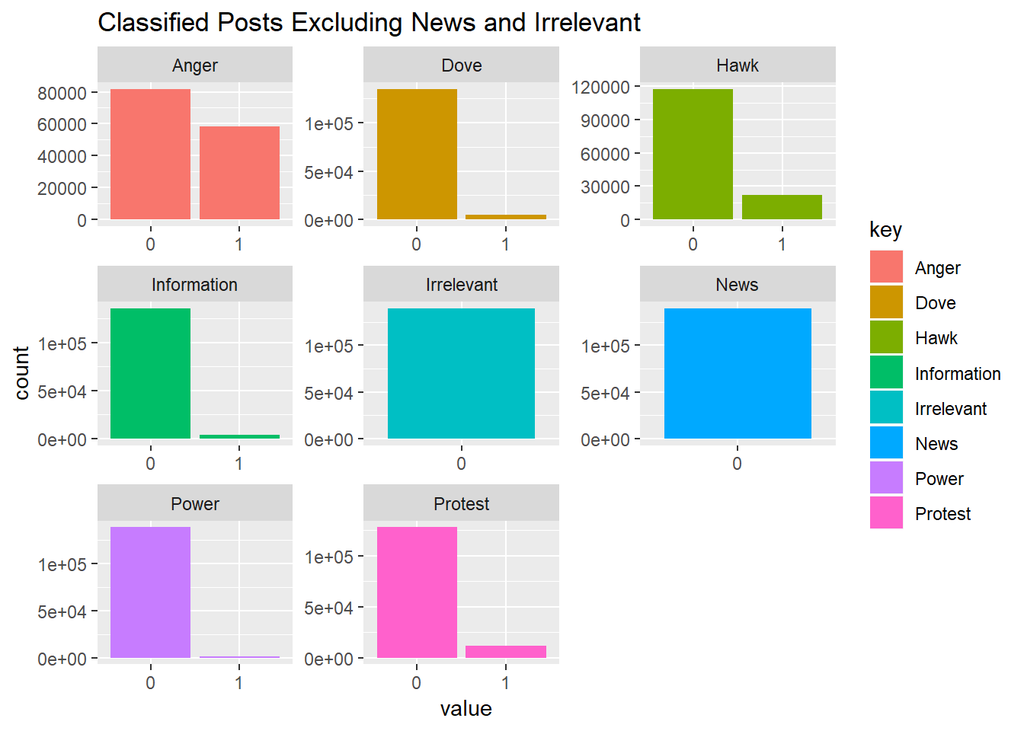

```r
library(bife)
library(margins)
library(broom)
library(knitr)

# loading cleaned, classified data
filtered_df <- readRDS(gzcon(url("https://github.com/14XZ/xzhang-811/raw/master/filtered_df.rds")))
dfplot <- readRDS(gzcon(url("https://github.com/14XZ/xzhang-811/raw/master/dfplot.rds")))

filtered_df %>%
  keep(is.factor) %>%                     # Keep only numeric columns
  gather() %>%                             # Convert to key-value pairs
  ggplot(aes(value, fill=key)) +                     # Plot the values
  facet_wrap(~ key, scales = "free") +   # In separate panels
  geom_bar() + ggtitle("Classified Posts Excluding News and Irrelevant")
```

Given that relevant posts are selected based on their relevance to the two international conflict escalation events between China and its neighbors, there are clear temporary variations in the number of relevant posts. Unsurprisingly, there are upsurges of relevant posts during the two crisis periods: the South China Sea standoff with the Philippines April 11 and late June, and the Diaoyu/Senkaku dispute escalation following the Japanese arrest of Chinese protesters on August 15, and following Japan’s decision to nationalize the island on September 11th. 78,574 posts relevant to two disputes are made during the two episodes of conflict escalation, constituting 56.16% of the relevant posts. The amount of attention also varies across events. The Diaoyu/Senkaku dispute escalation attracted far greater public attention from microblog users than the South China Sea standoff with the Philippines.

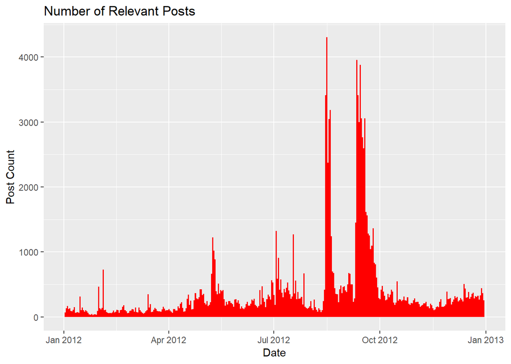

```r
ggplot(dfplot, aes(x=day, color=crisis)) +
  geom_histogram(fill="red", position="dodge",binwidth=1) + scale_color_manual(values=c("#377eb8","#e41a1c"))+
  theme(legend.position="none") +labs(title="Number of Relevant Posts",x="Date", y = "Post Count") +scale_x_date()
```

```r
# user matching
length(unique(dfplot$uid))
```

```
## [1] 52529
```

```r
# Subset weight data before treatment
before <- dfplot %>%
  filter(crisis == 0) %>%
  dplyr::select(uid,Anger,day)

# subset weight data after treatment
after <- dfplot %>%
  filter(crisis == 1) %>%
  dplyr::select(uid,Anger,day)

# pair user posts
within_subject_diff <- inner_join(before,after,by= "uid")

within_subject_diff$within_sub_diff <- as.integer(within_subject_diff$Anger.y)- as.integer(within_subject_diff$Anger.x)

t.test(within_subject_diff$within_sub_diff)
```

```
##
##  One Sample t-test
##
## data:  within_subject_diff$within_sub_diff
## t = 29.6, df = 1690900, p-value < 2.2e-16
## alternative hypothesis: true mean is not equal to 0
## 95 percent confidence interval:
##  0.01484105 0.01694581
## sample estimates:
##  mean of x
## 0.01589343
```

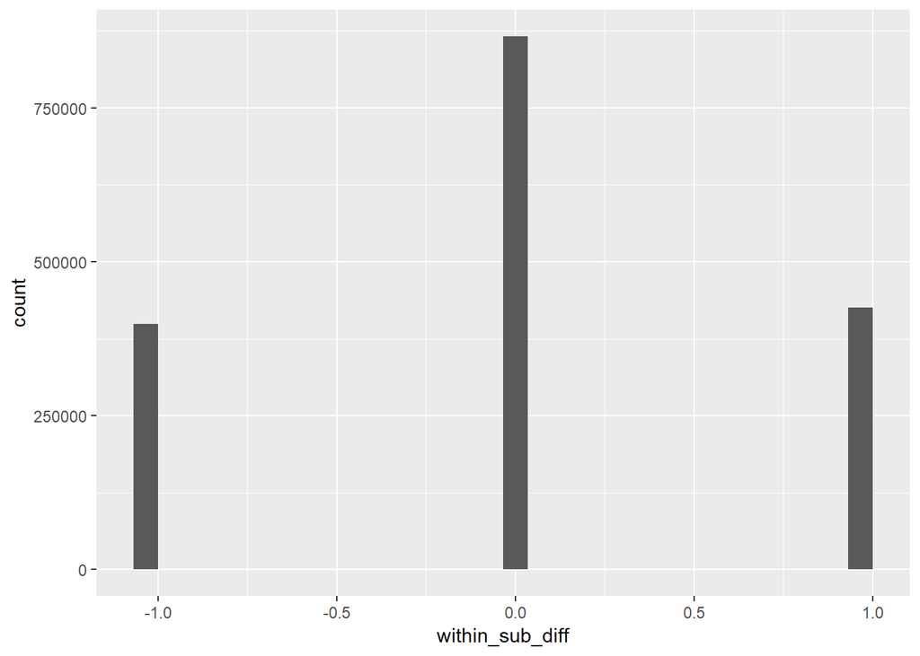

```r
ggplot(within_subject_diff, aes(within_sub_diff))+geom_histogram()
```

```r
userposts <- within_subject_diff %>%
  group_by(uid)%>%
  summarise(number = n())

summary(userposts$number)
```

```
##     Min.  1st Qu.   Median     Mean  3rd Qu.     Max.
##      1.0      2.0      4.0    225.3     16.0 310460.0
```

# Hypotheses:

I contend that when international dispute escalates, anger makes an individual less receptive to the influence of elite cue, and more hawkish. Specifically, I put three hypotheses to empirical tests: H_pervasiveness: Anger is a pervasive integral emotion in conflict H_hawkishness: Angry individual will express more hawkish foreign policy preference after independent of elite cues. H_information: angry individuals are likely to possess less information about a specific international dispute.

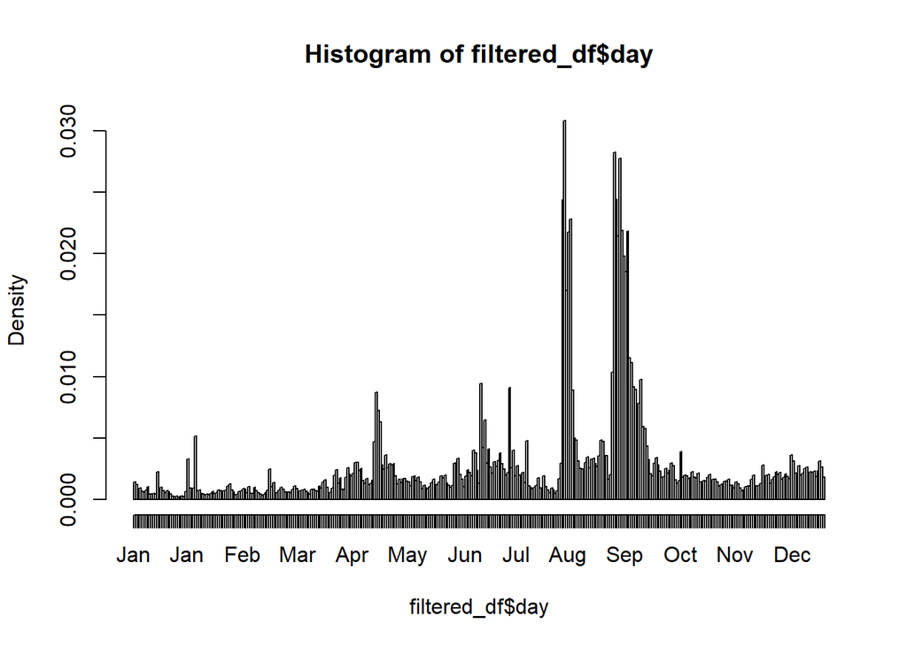

```r
hist(filtered_df$day, breaks = "days")
```

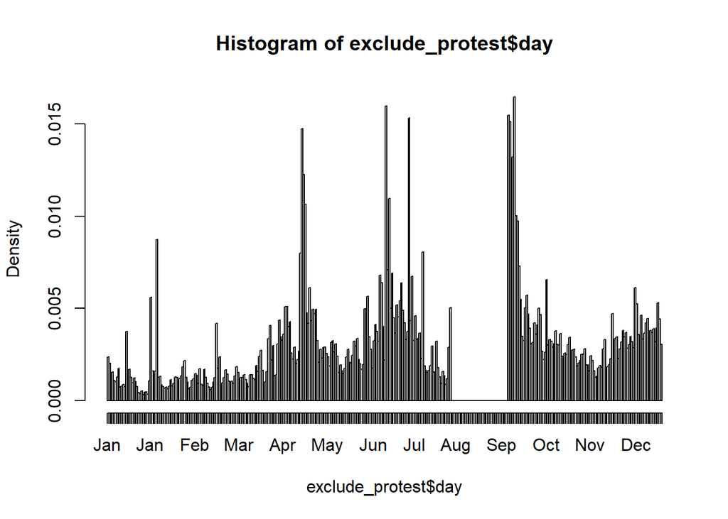

```r
exclude_protest <- filtered_df %>%
  filter(day < as.Date("2012-8-15") | day > as.Date("2012-09-20"))

summer_of_protest <- filtered_df %>%
  filter(day >= as.Date("2012-8-15") & day <= as.Date("2012-09-20"))

hist(exclude_protest$day, breaks = "days")
```

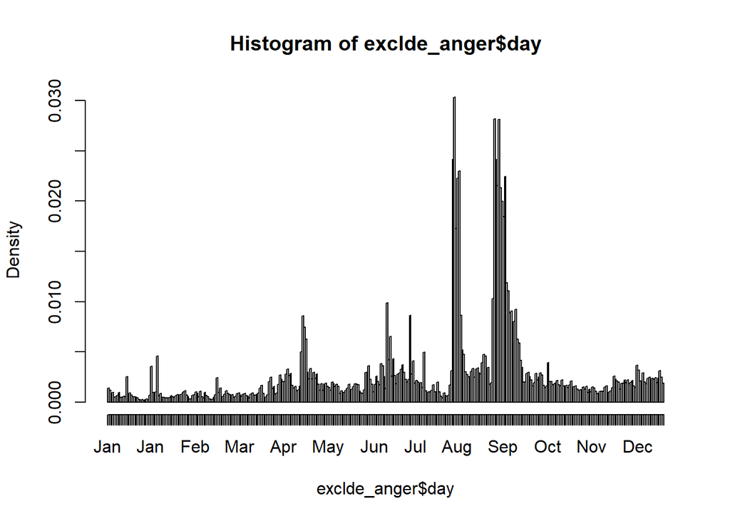

```r
exclde_anger <- filtered_df %>%
  filter(Anger == 0)

hist(exclde_anger$day, breaks = "days")
```

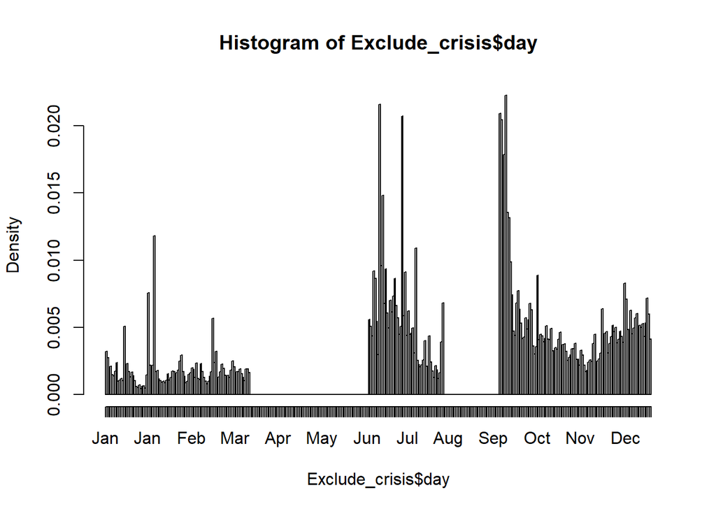

```r
SCS_only <- filtered_df %>%
  filter(SCS ==1)

Exclude_SCS_Standoff <- filtered_df %>%
  filter(day < as.Date("2012-04-08") | day > as.Date("2012-06-25"))

Exclude_crisis <- filtered_df %>%
  filter(day < as.Date("2012-04-08") | day > as.Date("2012-06-25") & day < as.Date("2012-8-15") | day > as.Date("2012-09-20") )


hist(Exclude_crisis$day, breaks = "days")
```

```r
m1 <- glm(formula = Hawk~ Anger, data = filtered_df, family = "binomial")
m2 <- glm(formula = Hawk~ Anger + HC_SCS + HC_ECS + Information + Power + ECS, data = filtered_df, family = "binomial") #main
m4 <- glm(formula = Hawk~ Anger + HC_SCS + HC_ECS + Information + Anger_cue + day + Power + ECS, data = filtered_df, family = "binomial")
m5 <- glm(formula = Hawk~ Anger + HC_SCS + HC_ECS + Information + Anger_cue  + day + Power + ECS, data = exclude_protest, family = "binomial")
m6 <- glm(formula = Hawk~ Anger + HC_SCS + HC_ECS + Information + Anger_cue  + day + Power + ECS, data = Exclude_crisis, family = "binomial")
```

# Results

Given that the dependent variable is binary, I use logistics regression models to estimate the association between anger and hawkishness as well as other competing explanatory variables. Model 1 provides a bivariate baseline estimation, showing a highly significant association with the hawkishness.

In interpreting the result of Model 2, it is worth articulating the expected direction of bias induced by measurement errors. Since anger and public post-level variables are classified using machine learning, measurement errors are inevitable, which would make it more difficult to reject the null hypothesis of no difference. The elite cue data, on the other hand, is hand-coded, that should involve far fewer measurement errors. Thus, the differential rate of measurement errors should make it easier to find a significant association between elite cue and hawkishness, and harder to find a significant association between hawkishness and anger. Nevertheless, despite the unfavorable direction of bias and large sample size, the statistical tests show a strong correlation between anger and hawkishness while no significant relationship between the hawkish elite cue and public hawkishness can be found. A closer reading of those social media posts would offer additional support to the statistical result revealing a lack of elite cue effect. Many microblog posts referencing the foreign ministry complain that elite cues on the disputes are “soft”, “cheap talk”, “only capable of lodging diplomatic protests” are some of the most frequent terms in posts referring elite cues. For example, one angry post made in December says that “Except shouting slogans, what else are the Foreign Ministry doing? [EXPLETIVE]! [Angry Emoji]”. There are ample examples of similar posts in the data. Rather than shaping public opinion on foreign policy, elite cues are often the object of frustration, mockery, and contempt. These results challenge the empirical expectation of the elite cue model that elite cue should have a strong sway over public opinion on foreign policy, particularly in authoritarian states. Model 3,4,5 offer three robustness checks on the statistical results. Model 3 tests the possibility that public anger is a function of elite emotion cue. In other words, the public might be following the elite cue when experiencing anger. Indeed, in more than a few occasions, Chinese foreign ministry spokesperson does provide anger cues pertinent to international disputes. For example, during the September 5th briefing, the spokesperson asserts that “disregarding repeated expression serious concern from China, Japan insists on continuing the island nationalization process, … hurting the national feelings of the Chinese people”. During the press briefing on September 11, 2012, addressing Tokyo’s decision to nationalize the disputed Diaoyu/Senkaku island, the spokesperson stated that “Erroneous actions taken by the Japanese side have triggered righteous anger among sons and daughters of the Chinese nation home and aboard” (Ministry of Foreign Affairs, 2012b). To adjust for the possibility of anger cue, I also include an anger cue indicator coded using the foreign ministry press briefing. However, the adjustment of anger cue does not change the main results. In a separate regression model omitted from the regression table, I found no significant association between elite anger cue and public anger either.

```r
stargazer(m1, m2, m4, m5, m6,
          title            = "Associations With Hawkish Posts",
          dep.var.labels   = "Hawkishness (Advocating the use of force)",
          covariate.labels = c("Anger", "Hawkish Cue (SCS)", "Hawkish Cue (ECS)",
                               "High Information", "Anger Cue", "Day",
                               "Confidence in National Power", "Post on the East China Sea Dispute"),
          type = "html")
```

**Associations With Hawkish Posts**

|  | *Dependent variable:* |  |  |  |  |
| --- | --- | --- | --- | --- | --- |
|  | Hawkishness (Advocating the use of force) |  |  |  |  |
|  | (1) | (2) | (3) | (4) | (5) |
| Anger | 0.639*** | 0.602*** | 0.602*** | 0.611*** | 0.627*** |
|  | (0.015) | (0.018) | (0.018) | (0.024) | (0.029) |
| Hawkish Cue (SCS) |  | 0.013 | 0.027 | 0.029 | 0.122 |
|  |  | (0.053) | (0.054) | (0.054) | (0.136) |
| Hawkish Cue (ECS) |  | -0.015 | -0.030 | -0.099** | -0.109*** |
|  |  | (0.023) | (0.026) | (0.041) | (0.042) |
| High Information |  | 0.526*** | 0.527*** | 0.458*** | 0.450*** |
|  |  | (0.044) | (0.044) | (0.061) | (0.074) |
| Anger Cue |  |  | 0.021 | -0.010 | 0.024 |
|  |  |  | (0.023) | (0.040) | (0.048) |
| Day |  |  | 0.0002 | 0.0002 | 0.0002 |
|  |  |  | (0.0002) | (0.0002) | (0.0003) |
| Confidence in National Power |  | 1.242*** | 1.242*** | 1.257*** | 1.286*** |
|  |  | (0.060) | (0.060) | (0.081) | (0.096) |
| Post on the East China Sea Dispute |  | -0.032 | -0.043** | -0.048* | -0.056* |
|  |  | (0.020) | (0.021) | (0.027) | (0.030) |
| Constant | -1.963*** | -1.959*** | -5.331** | -5.660** | -4.932 |
|  | (0.011) | (0.019) | (2.543) | (2.653) | (3.939) |
| Observations | 139,916 | 97,326 | 97,326 | 52,707 | 36,741 |
| Log Likelihood | -60,414.320 | -41,811.750 | -41,810.590 | -22,588.660 | -15,711.290 |
| Akaike Inf. Crit. | 120,832.600 | 83,637.500 | 83,639.180 | 45,195.320 | 31,440.580 |
| *Note:* | p<0.1; p<0.05; p<0.01 |  |  |  |  |

Model 4 considers the possibility that the association between anger and hawkish is driven by an event confounder – the nationwide anti-Japan protest regarding the Diaoyu/Senkaku island dispute between August 15th and September 20th, 2012. It is plausible that organized protest makes the public angrier and more hawkish at the same time. When the public attention is less concentrated on the disputes, elite cues might be more influential. To test the robustness of my primary findings to this possibility, I subset my data temporally for model 4 and model 5. For Model 4, I exclude the summer of protest. As shown, anger continues to have a strong positive association with hawkishness. Moreover, the hawkish elite cue on the East China Sea dispute become statistically significant. However, the negative direction of effect contradicts the empirical expectation of elite cue theory. In model 5, I exclude both the South China Sea and East China Sea dispute escalation episodes, my primary result on anger continues to stand, and hawkish elite cue on the East China Sea dispute with Japan now has a stronger, far more significant negative coefficient. One interpretation of these curious negative coefficients is that hawkish elite cue placated public demand for hawkish foreign policy, thus, reducing the likelihood of netizens to express hawkish views. Yet, even if this placation interpretation is valid, it should offer little solace to proponents of the elite cue model. The placation interpretation indicates that, if anything, elites are reacting to public preferences, at least rhetorically, instead of shaping public opinion through cues. These results are robust in two binary choice model with individual user fixed effects or the East China Sea fixed effect. Thus, the association between anger and hawkishness is unlikely to be contingent on particular characteristics of the escalation event or individual differences such as dispositional anger.

Additional regression analysis is performed to test the information hypothesis. Using information level in the post as the dependent variable, regressions result refutes my information hypothesis. In fact, there is a weak but statistically significant positive association between anger and political information in microblog posts. Measured in average marginal effect, angry posts are 1.3% more likely to contain details of international conflict and political knowledge. In this sample, angry posts are more likely to contain details and knowledge about international disputes. There are two interpretation of the positive association between anger and information. On the one hand, it is possible that an individual learning more about an international conflict becomes angrier. On the other hand, angry about an international dispute might motivate information seeking and closer attention to the relevant dispute.

These results are robust in two binary choice model with individual user fixed effects or the East China Sea fixed effect. Thus, the association between anger and hawkishness is unlikely to be contingent on particular characteristics of the escalation event or individual differences such as dispositional anger.

```r
fe <- bife(Hawk ~ Anger + HC_SCS + HC_ECS + Information  + day + Power |as.factor(uid), data = filtered_df, bias_corr = "ana")

# individual fixed effects
fe
```

```
## Fixed effects logit model
## with analytical bias-correction
##
## Uncorrected estimate(s)= 0.6809 0.0275 -0.0323 0.5932 1e-04 1.386
##
## Corrected estimate(s)= 0.6154 0.0233 -0.0289 0.5374 1e-04 1.2353
```

[figure not shown]

```r
#margianl effect
mf_m2<- margins(m2)
plot(mf_m2)
```

```r
# HC_SCS    HC_ECS       ECS  Anger1 Information1 Power1
# 0.001697 -0.001979 -0.004145 0.08146      0.08072 0.2289

summary(margins(m2, at = list(HC_SCS = c(0, 1)), variables = "Anger"))
```

```
##  factor HC_SCS    AME     SE       z      p  lower  upper
##  Anger1 0.0000 0.0814 0.0024 33.2848 0.0000 0.0766 0.0862
##  Anger1 1.0000 0.0821 0.0038 21.8657 0.0000 0.0748 0.0895
```

```r
# factor HC_SCS    AME     SE       z      p  lower  upper
# Anger1 0.0000 0.0814 0.0024 33.2848 0.0000 0.0766 0.0862
# Anger1 1.0000 0.0821 0.0038 21.8657 0.0000 0.0748 0s.0895

m2_c <- glm(formula = Hawk~ Anger + HC_SCS + HC_ECS + Information + Power + ECS, data = dfplot, family = "binomial")

summary(margins(m2_c, at = list(crisis = c(0, 1)), variables = "Anger"))
```

```
##  factor crisis    AME     SE       z      p  lower  upper
##  Anger1 0.0000 0.0815 0.0024 33.2830 0.0000 0.0767 0.0863
##  Anger1 1.0000 0.0815 0.0024 33.2830 0.0000 0.0767 0.0863
```

```r
# factor crisis    AME     SE       z      p  lower  upper
# Anger1 0.0000 0.0815 0.0024 33.2830 0.0000 0.0767 0.0863
# Anger1 1.0000 0.0815 0.0024 33.2830 0.0000 0.0767 0.0863
```